# Probability Homework

Matthew Johnson

September 6, 2017

1. The balloons probability is just out of 25 balloons, 10 yellow, 8 red, 7 green. This means probability of getting a yellow is 10/25. The probability of popping a second yellow balloon is one less yellow balloon out of the total balloons after a balloon popped, so 9/24. So the combination of the two means AND, meaning multiplication. so 10/25 * 9/24.

```r
prob_yellow <- 10/25
prob_second_yellow <- 9/24
(prob_two_yellow <- prob_yellow*prob_second_yellow)
```

```
## [1] 0.15
```

```r
ToothGrowth$dose <- as.factor(ToothGrowth$dose)
names(ToothGrowth)
```

```
## [1] "len"  "supp" "dose"
```

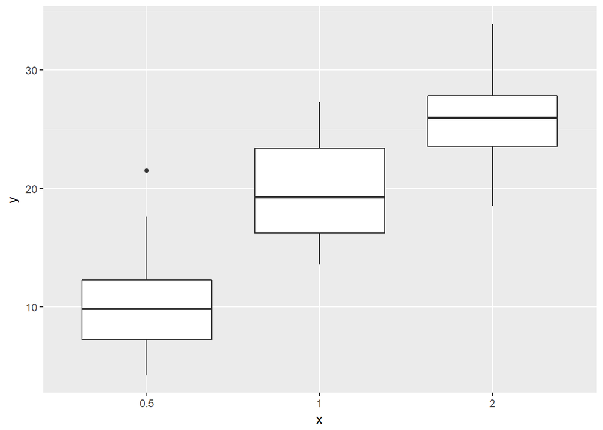

```r
x <- ToothGrowth$dose
y <- ToothGrowth$len
ggplot2::qplot(x, y, geom = "boxplot")
```

3. So ABC are sequential and its output is then input into a parallel system of DEF. So we have to take the probability of all ABC fails and THEN the possiblity of ABCD failing, ABCE failing, and ABCF failing. So if any ABC fail, the system is down, so A OR B OR C. If all D, E, and F fail, the system goes down. so D AND E AND F.

```r
A <- 0.1
B <- 0.15
C <- 0.2
D <- 0.9
E <- 0.85
F <- 0.8

#P(A or B or C) and P(D and E and F)
((A + B + C) * (D * E * F))
```

```
## [1] 0.2754
```

```r
groceries <- read.csv("C:/Programming/R stuff/groceries.csv")
# calculating the support of the different associations - P(A&B)
curd_cereals_wholemilk <- mean(groceries$curd & groceries$cereals & groceries$whole.milk)
curd_cereals_wholemilk
```

```
## [1] 0.001016777
```

```r
yogurt_cereals_wholemilk <- mean(groceries$yogurt & groceries$cereals & groceries$whole.milk)
yogurt_cereals_wholemilk
```

```
## [1] 0.001728521
```

```r
liquor_redwine_bottledbeer <- mean(groceries$liquor & groceries$red.blush.wine & groceries$bottled.beer)
liquor_redwine_bottledbeer
```

```
## [1] 0.001931876
```

```r
# calculating the confidence of the different associations - P(A&B)/P(A)
curd_cereals_wholemilk_conf <- mean(groceries$curd & groceries$cereals & groceries$whole.milk)/groceries$whole.milk
curd_cereals_wholemilk_conf
```

[output not shown]

[output cut: 1952 more lines]

```r
yogurt_cereals_wholemilk_conf <- mean(groceries$yogurt & groceries$cereals &groceries$whole.milk)/groceries$whole.milk
yogurt_cereals_wholemilk_conf
```

[output not shown]

[output cut: 1952 more lines]

```r
liquor_redwine_bottledbeer_conf <- mean(groceries$liquor & groceries$red.blush.wine & groceries$bottled.beer)/groceries$bottled.beer
liquor_redwine_bottledbeer_conf
```

[output not shown]

[output cut: 1952 more lines]

```r
# calculating the lift of the different associations - LIft = P(A&B)/(P(A)*P(B))
curd_cereals_wholemilk_lift <- mean(groceries$yogurt & groceries$cereals &groceries$whole.milk)/(curd_cereals_wholemilk*groceries$whole.milk)
curd_cereals_wholemilk_lift
```

[output not shown]

[output cut: 564 more lines]

```r
yogurt_cereals_wholemilk_lift <- mean(groceries$yogurt & groceries$cereals &groceries$whole.milk)/(yogurt_cereals_wholemilk*groceries$whole.milk)
yogurt_cereals_wholemilk_lift
```

[output not shown]

[output cut: 564 more lines]

```r
liquor_redwine_bottledbeer_lift <- mean(groceries$liquor & groceries$red.blush.wine & groceries$bottled.beer)/(liquor_redwine_bottledbeer*groceries$bottled.beer)
liquor_redwine_bottledbeer_lift
```

[output not shown]

[output cut: 564 more lines]